# Projected seasonal climate trends

### Anchorage, Alaska

> Projected seasonal changes in temperature and precipitation

These climate graphs show projected changes in seasonal temperature and precipitation for Anchorage, Alaska. (Top) Annual time series of projected delta change for 2020 - 2099 based on five climate models and three greenhouse gas emissions scenarios. (Bottom) Average seasonal change for the 2070 - 2099 period compared to the 1960 - 1989 historical baseline.

The top splits temperature and precipitation projections onto two tabs. All graphs shows projections for each three-month seasonal period. Seasons are defined with winter beginning from prior year December through current year February (DJF) and so on (MAM, JJA, SON). Historical baseline climatologies are also seasonal for making delta change comparisons between seasons.

Results shown are based on SNAP’s 2-km downscaled gridded AR5/CMIP5 climate model outputs and historical CRU data, extracted in the vicinity of Anchorage, Alaska. Estimations and graphs are made with the R programming language and presented using `flexdashboard`.

[interactive chart not shown]

### Projected seasonal temperature deltas

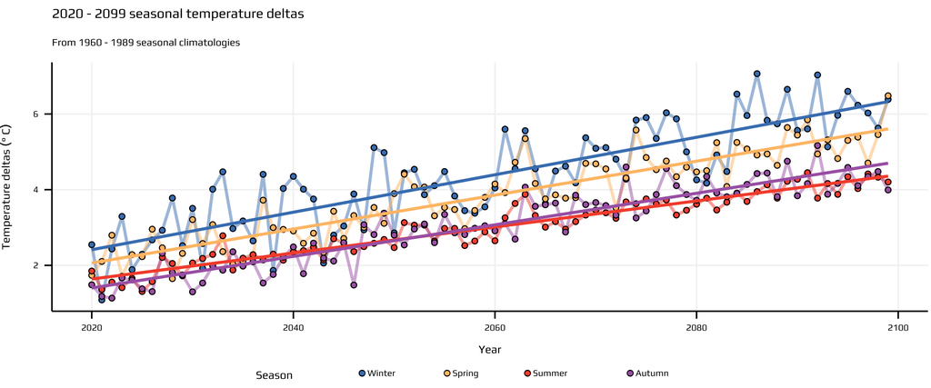

### Projected seasonal precipitation deltas

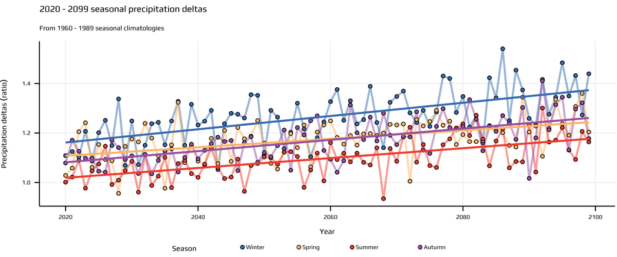

### Mean temperature change from baseline

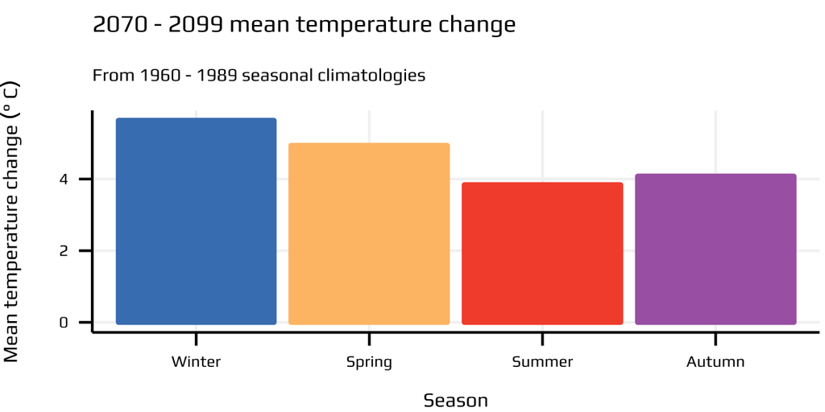

### Mean precipitation change from baseline

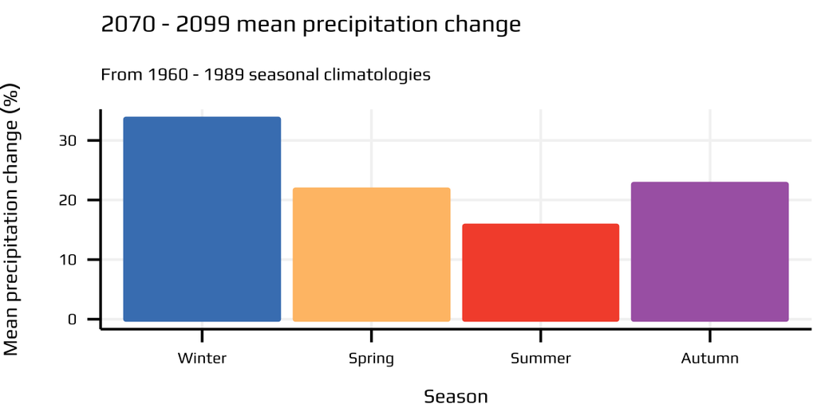